# Predicting Bike Share Usage in Chicago

Yizhou Chen & Haishan Wu

December 15th, 2017

## **1 Introduction**

As completing its protected bike lanes in spring 2017, Chicago became the first major U.S. city with a downtown network of protected bike lanes. The nation’s second-largest bike share system, Divvy, has always been trying to provide the best service to its users. Our proposal aims to help Divvy building a more effective and efficient bicycle balancing application.

However, currently Divvy suffers from a fundamental problem. Their docking stations around the city are often completely empty when users need to use bicycles, or completely filled when users need to park their bikes. This situation causes users significant inconvenience, which ultimately causes Divvy losing business.

One possible solution is to rebalance bicycles in stations by redistribution trucks in advance, thus preventing completely empty or filled docking stations. But this approach requires accurate prediction of future bike demand at each station, so that the operators can determine when, at which station and how many bikes needed to be relocated.

Our model will help to predict number of bike departures at each station in an hour. If proved robust, our model can help guiding preemptive rebalancing of Divvy system, and hopefully better solve the current problem. Besides Chicago, other cities which currently have or may encounter similar problem in the future, may also employ this method for better management.

## **2 Data**

### 2.1 Dependent Variable

The dependent variable in our model is the **number of departures at each station in each hour**. We first selected 150 Divvy stations that are closest to center of Loop, and downloaded bike trip records at selected stations from 5/7/2017 to 5/13/2017 (https://www.divvybikes.com/system-data). The raw data includes starting station, day and time of each trip. We then calculated the count of bike departures at each station by hour, however, for those hours with no trip taken place, we assigned them to a value of 0.

### 2.2 Independent Variables

There are two categories of independent variables in our model — temporal and spatial. All independent variables were selected based on a series of hypotheses.

#### Temporal

- Hypothesis 1: There is a pattern for the bike share usage in Chicago. Bike rental demands are higher in certain days of the week or certain hours during the day than other times. Therefore, we include **days in a week** and **hours in a day** as two independent variables in our model. These two variables are included in the Divvy bike trip data.
- Hypothesis 2: Furthermore, weather has an impact on people’s willingness of using bike share. People may not be willing to use bike share when it is too cold, too hot or rainy. So we also choose hourly **temperature** and **precipitation** as independent variables. The data is retrieved from Weather Underground website (https://www.wunderground.com/history/airport/KORD/).
- Hypothesis 3: Number of departures from a station in a particular hour is associated with the number of departures from this specific station such an hour before. Thus we use the **temporal lag** as an independent variable.

#### Spatial

- Hypothesis 4: High density of bike stations and bike lanes may encourage the usage of bike share, because it makes bike sharing more accessible and convenient for users. So we calculate **average distance to 10 nearest Divvy stations** and **bike lane density** and use them as independent variables. Data related to both Divvy stations and bike lanes is retrieved from Chicago Data Portal (https://data.cityofchicago.org/).
- Hypothesis 5: Even though bus stops density might be positively correlated with traffic demand, but bus transit service also can also be a competitor to bike share. We use the **number of bus stops within a certain distance** as an independent variable. However, we cannot determine what kind of relationship are there between this independent variable and the dependent variable. The distance threshold is calculated as the average distance from each Divvy station to 10 nearest bus stops. The data of bus stops is also retrieved from Chicago Data Portal.
- Hypothesis 6: The number of departure from a station is associated with the number of departure from its neighboring stations. Thus, the **spatial lag** is also included as an independent variable. Because we are predicting bike trip departures in the future and don’t know future departure counts from neighboring stations, the spatial lag is calculated as average number of departures from 10 nearest stations in the hour before.

```r
names(trip6)
```

```
##  [1] "weekday"           "hour"              "from_station_id"
##  [4] "trip_count"        "temp.lag"          "spat.lag"
##  [7] "near_dist"         "bus_dist"          "temperature"
## [10] "precipitation"     "bike_lane_density"
```

## **3 Exploratory Analysis**

### 3.1 Distribution of Dependent Variable

We first look at the histogram of our dependent variable — the number of departures at each station in each hour. The distribution of dependent variable can help determining which regression method to choose. An OLS regression assumes that the dependent variable has a normal distribution, while a poisson regression assumes a poisson distribution. According to the histogram, the data consists of mostly low values (e.g. counts of 0, 1, 2) and less frequently higher values (illustrated by a long right tail). This feature seems to be closer to a poisson distribution rather than a normal distribution. So we consider that a poisson regression is more appropriate than an OLS regression in this case.

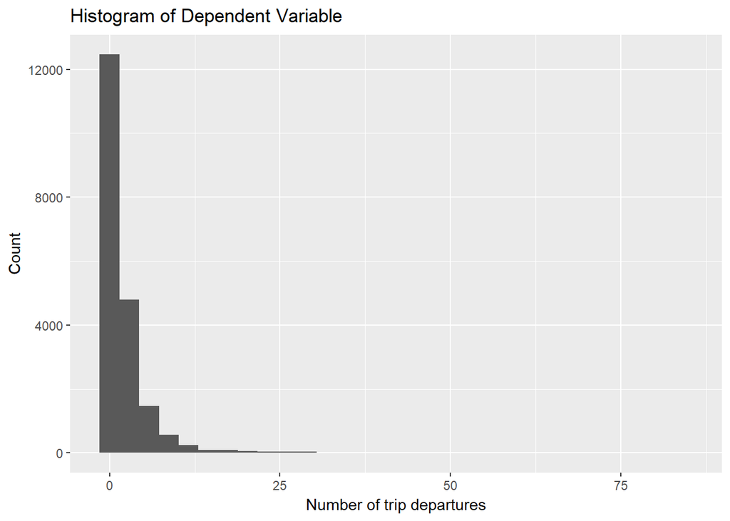

```r
ggplot()+
  geom_histogram(data = trip6,aes(trip_count),bins=30)+
  labs(x="Number of trip departures",
       y="Count",
       title="Histogram of Dependent Variable")
```

Then we will look at the distribution of dependent variable on space and time series. For spatial distribution, we sum up the total number of bike departures within the sample week at each station. We can see strong spatial autocorrelation in number of trip departures. Stations with more trip departures tend to be clustered in the central area, while stations with much less trips are likely located on the outskirts. Including the spatial lag variable in our model will help explain the spatial pattern in the dependent variable.

```r
# Map of Chicago
chicago <- get_map(location = "Chicago",
                   zoom = 13,
                   maptype = "toner-lite",
                   source = "stamen")

# Sum of trip counts at each station
trip.bystation <- trip1 %>%
  group_by(from_station_id) %>%
  summarise(count_station=sum(trip_count)) %>%
  left_join(station,by=c("from_station_id"="id"))
```

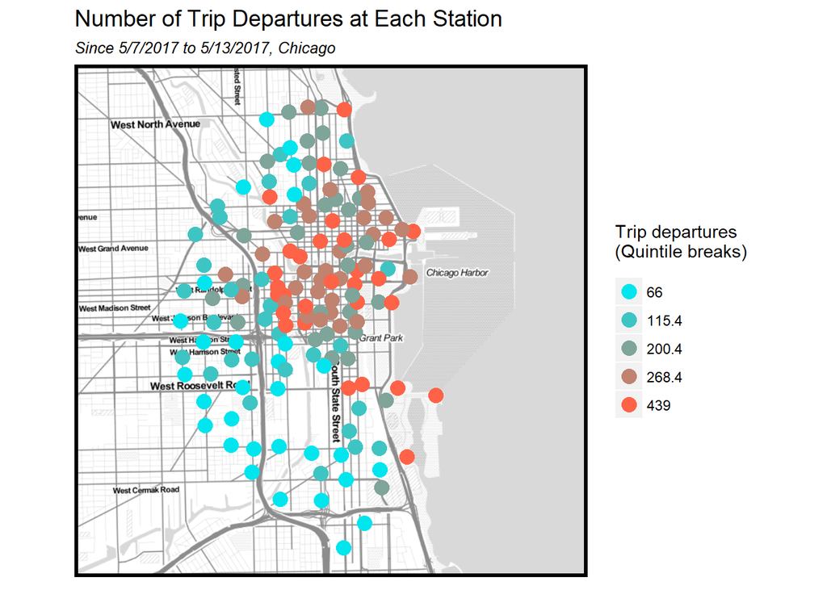

```r
ggmap(chicago)+
  geom_point(data = trip.bystation,aes(longitude,latitude,color=factor(ntile(count_station,5))),size=4)+
  scale_color_manual(labels=as.character(quantile(trip.bystation$count_station,
                                                  c(.1,.2,.4,.6,.8),na.rm=T)),
                     values = colorRampPalette(c("turquoise2","tomato"))(5),
                     name="Trip departures\n(Quintile breaks)")+
  labs(title="Number of Trip Departures at Each Station",
       subtitle="Since 5/7/2017 to 5/13/2017, Chicago")+
  mapTheme()
```

For time series, we sum up the total number of bike departures in each hour. Evidently, there are a large amount of bike departures between 8 a.m. and 5 p.m., and very few trips from 0 to 4 a.m. Since too many zero values in our dataset might affect the model quality, and bikes rebalancing during midnight is definitely meaningless, we decide to remove the observations between 0 and 4 a.m.

```r
# Sum of trip counts in each hour
trip.byhour <- trip1 %>%
  group_by(hour) %>%
  summarise(count_hour=sum(trip_count))
```

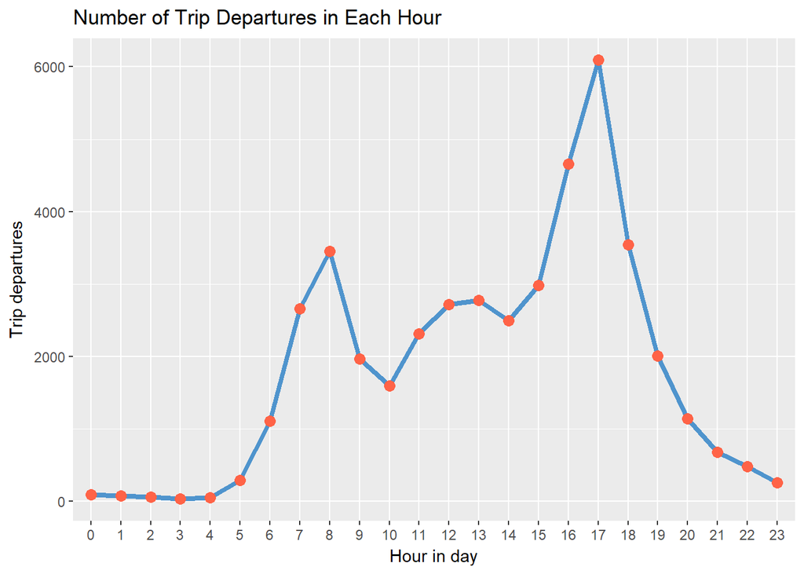

```r
ggplot(data = trip.byhour,aes(hour,count_hour,group=1))+
  geom_line(size=1.5,color="steelblue3") +
  geom_point(size=3,color="tomato")+
  labs(x="Hour in day",
       y="Trip departures",
       title="Number of Trip Departures in Each Hour")
```

The sample autocorrelation function (ACF) can be used to identify the possible structure of time series data. It gives correlations between the data series and lagged values of the series for lags of 1, 2, 3, and so on. As shown in the graph, the number of trip departures is most strongly correlated with that of an hour before. A value higher than the blue line also indicates that the correlation is statistically significant. In conclusion, we will use the number of trip departures in an hour before as the temporal lag variable.

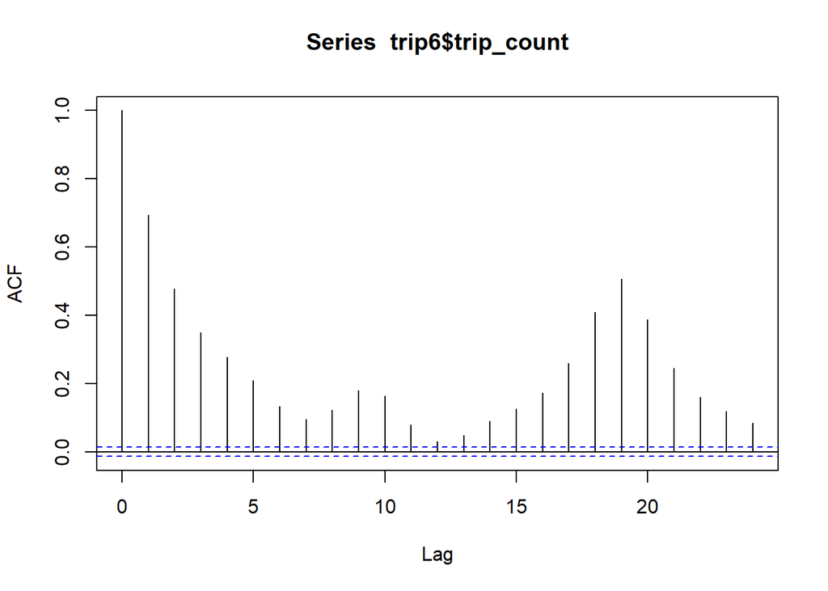

```r
acf(trip6$trip_count,lag.max = 24)
```

### 3.2 Summary Statistics

The following table shows the summary statistics of all numeric variables in our model.

```r
stargazer(trip6, type="text", title = "Summary Statistics")
```

```
##
## Summary Statistics
## ========================================================
## Statistic           N     Mean   St. Dev.  Min     Max
## --------------------------------------------------------
## trip_count        19,950  2.165   4.287     0      84
## temp.lag          19,950  2.154   4.289     0      84
## spat.lag          19,950  2.122   2.625   0.000  25.400
## near_dist         19,950 188.375  56.133  66.877 313.748
## bus_dist          19,950  4.553   1.043     2       7
## temperature       19,950 56.129   9.317   37.000 81.000
## precipitation     19,950 0.0005   0.004   0.000   0.040
## bike_lane_density 19,950  4.869   3.238   0.000  17.749
## --------------------------------------------------------
```

Since we are going to build a linear regression model, it is necessary to test whether the independent variables are strongly correlated with each other. The Correlation Matrix allows us to check the independence between predictors, which ensure that predictors are not interfering each other. A value equal to or greater than 0.8 is a general standard for severe correlation between predictors, which means predictors are interfering with each other and our estimation could be wrong. Since all the values of correlation are less than 0.8, we cannot conclude severe correlation between our predictors. All predictors can be included in the model.

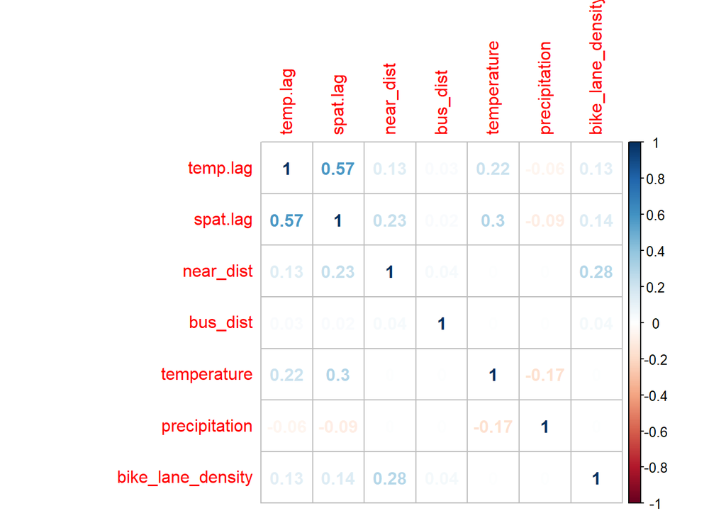

```r
M <- cor(trip6 %>% dplyr::select(-trip_count,-weekday,-hour,-from_station_id))
corrplot(M, method = "number")
```

## **4 Modeling Approach**

In this section we will determine which predictors should be included in the final model. We add each predictor to the regression model stepwise, and determine whether we should include the specific predictor based on two criteria — 1. is the predictor statistically significant? And, 2. does the model quality being improved by adding this predictor? The Akaike Information Criterion (AIC) is used for comparing models’ quality. Generally, the AIC offers an estimate of the relative information lost when a given model is used to represent the process that generated the data. And it deals with the trade-off between the goodness of fit of the model and the complexity of the model. In practice, a lower AIC value implies a relatively better model quality.

```r
# Poisson regression model
reg8 <- glm(trip_count ~ ., family = "poisson",
            data= trip6 %>%
              dplyr::select(-from_station_id))
```

```r
summary(reg8)
```

```
##
## Call:
## glm(formula = trip_count ~ ., family = "poisson", data = trip6 %>%
##     dplyr::select(-from_station_id))
##
## Deviance Residuals:
##      Min        1Q    Median        3Q       Max
## -10.6080   -1.3592   -0.6856    0.4383   11.9804
##
## Coefficients:
##                       Estimate   Std. Error z value             Pr(>|z|)
## (Intercept)        -2.76078425   0.08905534 -31.001 < 0.0000000000000002
## weekday2            0.33105373   0.02148975  15.405 < 0.0000000000000002
## weekday3            0.19024593   0.02222148   8.561 < 0.0000000000000002
## weekday4            0.06118968   0.02465944   2.481             0.013087
## weekday5            0.27444187   0.02419415  11.343 < 0.0000000000000002
## weekday6            0.27177057   0.02734170   9.940 < 0.0000000000000002
## weekday7            0.06268936   0.03880924   1.615             0.106241
## hour6               1.19811168   0.06770504  17.696 < 0.0000000000000002
## hour7               1.88755345   0.06418608  29.408 < 0.0000000000000002
## hour8               1.64212950   0.06481022  25.338 < 0.0000000000000002
## hour9               0.97112888   0.06774800  14.334 < 0.0000000000000002
## hour10              1.15174115   0.06906225  16.677 < 0.0000000000000002
## hour11              1.55107068   0.06875794  22.558 < 0.0000000000000002
## hour12              1.58952423   0.06847392  23.214 < 0.0000000000000002
## hour13              1.52310005   0.06932710  21.970 < 0.0000000000000002
## hour14              1.35586226   0.06989096  19.400 < 0.0000000000000002
## hour15              1.54350669   0.06931671  22.267 < 0.0000000000000002
## hour16              1.95064376   0.06831593  28.553 < 0.0000000000000002
## hour17              1.92914778   0.06751917  28.572 < 0.0000000000000002
## hour18              1.05166135   0.06819023  15.422 < 0.0000000000000002
## hour19              1.15225274   0.06742930  17.088 < 0.0000000000000002
## hour20              0.85738227   0.06920639  12.389 < 0.0000000000000002
## hour21              0.49767644   0.07283711   6.833  0.00000000000833126
## hour22              0.22409019   0.07683877   2.916             0.003541
## hour23             -0.28056348   0.08611065  -3.258             0.001121
## temp.lag            0.04894335   0.00041443 118.097 < 0.0000000000000002
## spat.lag            0.07584321   0.00166252  45.620 < 0.0000000000000002
## near_dist           0.00224699   0.00009162  24.525 < 0.0000000000000002
## bus_dist            0.03603953   0.00453260   7.951  0.00000000000000185
```

[output cut: 31 more lines]

```
## near_dist         ***
## bus_dist          ***
## temperature       ***
## precipitation     ***
## bike_lane_density ***
## ---
## Signif. codes:  0 '***' 0.001 '**' 0.01 '*' 0.05 '.' 0.1 ' ' 1
##
## (Dispersion parameter for poisson family taken to be 1)
##
##     Null deviance: 90653  on 19949  degrees of freedom
## Residual deviance: 46971  on 19918  degrees of freedom
## AIC: 79344
##
## Number of Fisher Scoring iterations: 6
```

We can then calculate the absolute standardized coefficients for preditors. The parameters are interpreted as standard deviation change in the dependent variable, with respect tp per standard deviation change in the predictors. Standardized coefficients facilitate an assessment of which variable has the greatest association with the dependent variable. Because there are fixed effects for days in week and hours in day in our model, we are going to calculate standardized coefficients by the following code. According to the results, the temporal lag and spatial lag variables have the strongest association with the dependent variable, while the bike lane density and bus stops have the weakest association.

```r
b <- summary(reg8)$coef[-1,1][25:31]
sx <- apply(reg8$model[4:10],2,sd)
sy <- sd(trip6$trip_count)
beta <- b * sx/sy
standardized <- data.frame(absCoef=abs(beta),
                           variable=names(beta))
```

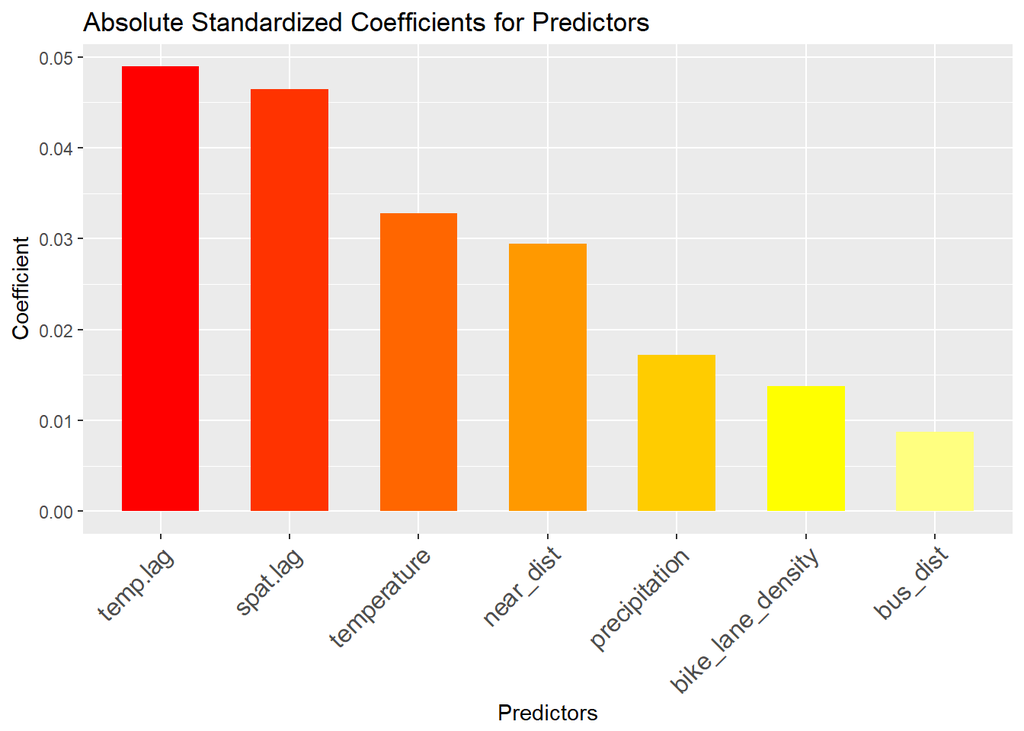

```r
ggplot(standardized, aes(x=reorder(variable,-absCoef), y=absCoef, fill=reorder(variable,-absCoef))) +
  geom_bar(stat="identity",width = 0.6)+
  scale_fill_manual(values = heat.colors(7,1))+
  theme(axis.text.x = element_text(angle = 45, hjust = 1,size = 12),
        legend.position="none")+
  labs(x="Predictors",y="Coefficient",
       title="Absolute Standardized Coefficients for Predictors")
```

## **5 Model Quality**

To assess model quality, we select bike trips in the following two days — 5/14/2017 and 5/15/2017 — as test set and use our model to predict bike departures at each station in each hour. The root mean squared logarithmic error (RMSLE) is often used for evaluating prediction performance of a poisson regression model. RMSLE shows the overall accuracy of prediction and is better than RMSE since it mitigates the bias caused by large values. According to the results, RMSLE is 0.655 for training set, and 0.722 for test set. Because the training set error is lower than the test set error, the current model is not performing as well on an unknown dataset as on a known dataset.

```r
# RMSLE of training set
trainset <- data.frame(observed=trip6$trip_count,
                       predicted=reg8$fitted.values) %>%
  mutate(logerror=log(predicted+1)-log(observed+1))
rmsle.train <- (mean(trainset$logerror^2))^(1/2)
# RMSLE of test set
testset <- data.frame(observed=trip.test$trip_count,
                      predicted=predict.glm(reg8,trip.test,type = "response")) %>%
  mutate(logerror=log(predicted+1)-log(observed+1))
rmsle.test <- (mean(testset$logerror^2))^(1/2)
```

```r
data.frame(rmsle.training=rmsle.train,
           rmsle.test=rmsle.test)
```

```
##   rmsle.training rmsle.test
## 1      0.6549205  0.7223586
```

```r
fitControl <- trainControl(method = "cv", number = 20)
set.seed(825)
lmFit1 <- train(trip_count ~ .,
                data= trip6 %>%
                  dplyr::select(-from_station_id),
                method = "glm", family = "poisson",
                trControl = fitControl)
cv <- gather(lmFit1$resample,"statistics","value",c(RMSE,MAE))
```

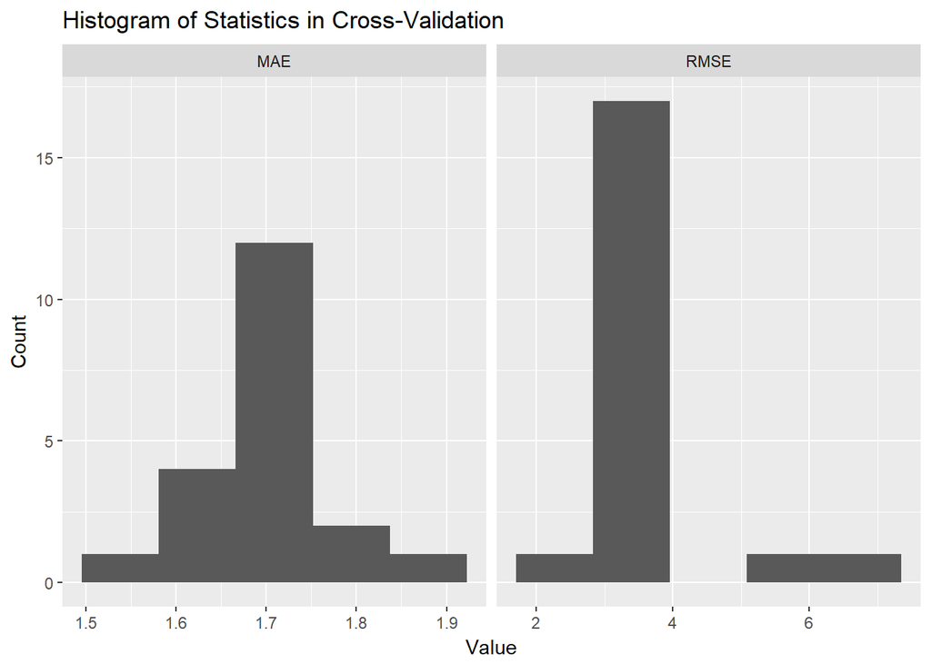

```r
ggplot(cv, aes(value)) +
  geom_histogram(bins = 5) +
  facet_wrap(~statistics,scales = "free_x") +
  labs(x="Value",
       y="Count",
       title="Histogram of Statistics in Cross-Validation")
```

After testing the generalizability of our model with cross-validation, now we test whether our model successfully explains the temporal and spatial patterns in the dependent variable. First we sum up the observed and predicted number of trip departures by hours in day. Overall, the prediction can fit the trend of actual departures very well, even though there is evident overprediction at 5 and 6 p.m., when the number of departures are greatest.

```r
# Predict the number of departure by our model
trip.predict <- trip.test %>%
  mutate(prediction=predict.glm(reg8,trip.test,type = "response"),
         error=prediction-trip_count)

# Sum trip departures by hour in day
trip.predict.hour <- trip.predict %>%
  group_by(hour) %>%
  summarise(actualCount=sum(trip_count),
            predictedCount=sum(round(prediction))) %>%
  gather("method","value",actualCount:predictedCount)
```

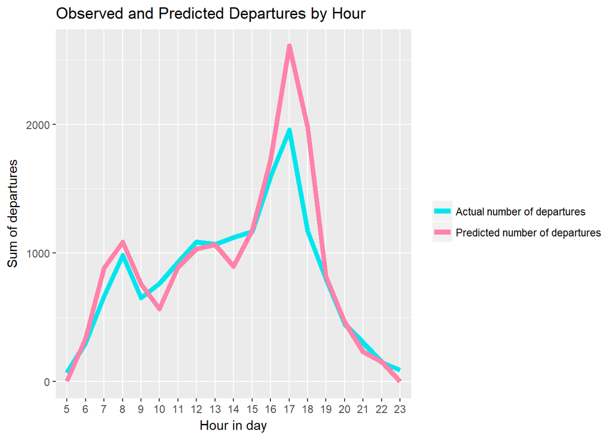

```r
ggplot(trip.predict.hour,aes(hour,value,group=method)) +
  geom_line(aes(color=method),size=2) +
  scale_color_manual(values = c("turquoise2","palevioletred1"),
                     labels=c("Actual number of departures",
                              "Predicted number of departures"),
                     name="") +
  labs(x="Hour in day",
       y="Sum of departures",
       title="Observed and Predicted Departures by Hour")
```

Then we look at the sample autocorrelation function (ACF) of model errors to test if there is still temporal pattern in errors. The graph below does not show any strong correlation between the data series and lagged values. This indicates that the temporal pattern in dependent variable is well-explained by our model.

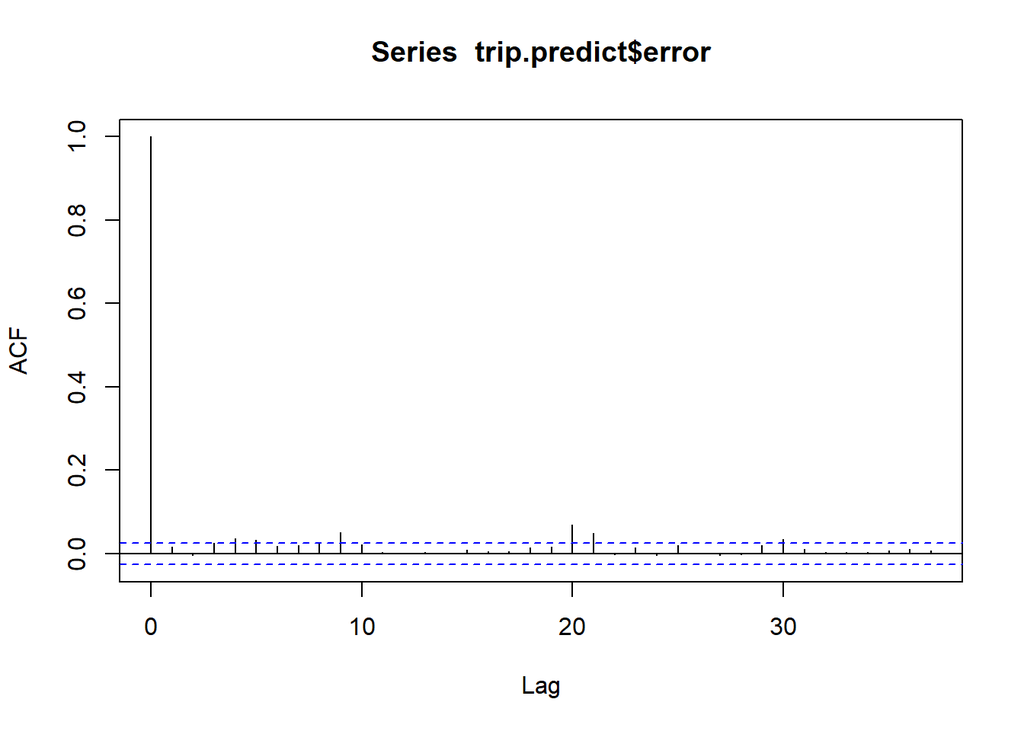

```r
acf(trip.predict$error)
```

After that, in order to test whether our model can explain the spatial pattern in the dependent variable, we sum up the observed and predicted number of trip departures by each station, and calculate the percent error at each station. The map below shows that spatial autocorrelation in model errors is still strong. The percent errors in central area are mostly low, but those on the outskirts are relatively high, which indicates a limitation of our model. But, considering our use case, we are not too concerned about this issue, because bike rebalancing is definitely a priority in high-demand areas rather than in areas with few bike trips.

```r
trip.predict.station <- trip.predict %>%
  group_by(from_station_id) %>%
  summarise(actualCount=sum(trip_count),
            predictedCount=sum(prediction)) %>%
  mutate(abserror=abs(predictedCount-actualCount),
         percent_error=abserror/actualCount) %>%
  left_join(station,by=c("from_station_id"="id"))
```

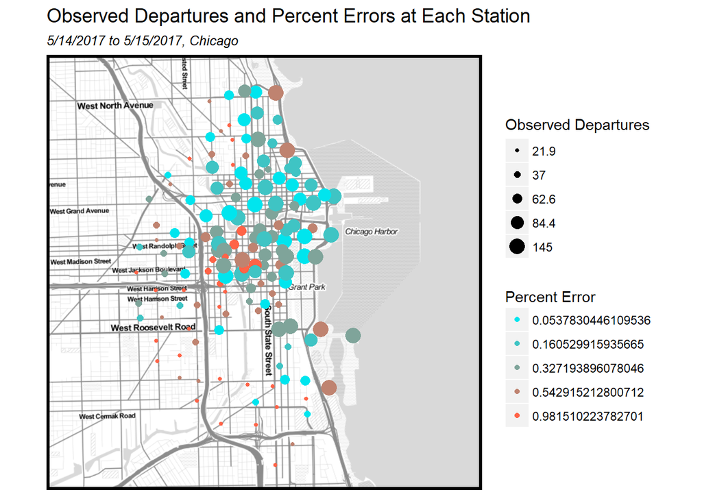

```r
ggmap(chicago)+
  geom_point(data = trip.predict.station,
             aes(longitude,latitude,color=factor(ntile(percent_error,5)),size=factor(ntile(actualCount,5)))) +
  scale_color_manual(labels=as.character(quantile(trip.predict.station$percent_error,
                                                  c(.1,.2,.4,.6,.8),na.rm=T)),
                     values = colorRampPalette(c("turquoise2","tomato"))(5),
                     name="Percent Error") +
  scale_size_manual(labels=as.character(quantile(trip.predict.station$actualCount,
                                                 c(.1,.2,.4,.6,.8),na.rm=T)),
                    values = c(1,2,3,4,5),
                    name="Observed Departures") +
  labs(title="Observed Departures and Percent Errors at Each Station",
       subtitle="5/14/2017 to 5/15/2017, Chicago") +
  mapTheme()
```

In summary, we are predicting better (low percent errors) at stations with more trip departures than those with less, according to the map. Although our model does not explain the spatial pattern in the dependent variable well, it can predict accurately at those popular stations where bike rebalancing is the most needed.

## **6 Discussion**

In this project, we predict the number of bike departures at each station in each hour by a series of predictors. Results show that our model is generalizable, and able to explain the temporal pattern in bike trip departures. Our model performs well on areas where bike shares is popular, even though it is desirable if it could better explain all the spatial pattern in bike departures. Based on real-time counts of bike departures at each station, our model can predict bike departures in the following hours. Ultimately, it achieves the goal of guiding the bike rebalancing.

As to some potential improvements of our model, we suggest including more predictors that may be associated with the dependent variable, especially spatial related predictors. Also, we advise to consider other machine learning models that may be more suitable and preferable for this problem, because there are some limitations of our model. One limitation of this model is that the training set only consists of data from one week so that it might not be generalizable on other time period. It is more appropriate to train the model on one-year data, because that’s more likely to build a better predictive model. Another limitation is that we only analyze on the bike share demand. To better guide the rebalancing work, it is necessary to analyze the supply side as well, which means to predict bike trip arrivals at each station.